# Лабораторная работа №4

## Использование rpm

Получем дополнительную информацию о содержимом пакета, введя: *rpm -qi lynx* (рис. 29)

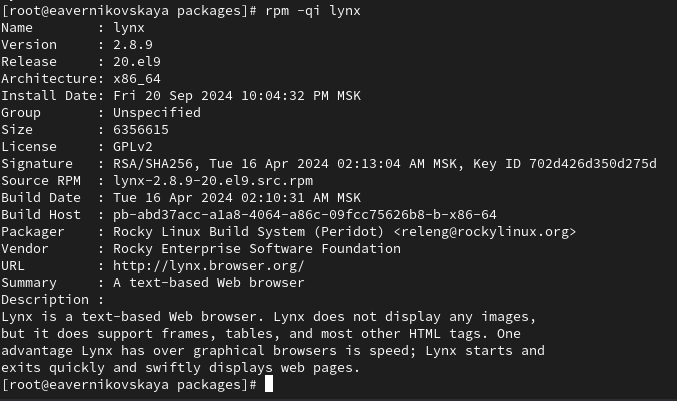

Информация о содержимом пакета (lynx)

## Использование rpm

Получаем список всех файлов в пакете, используя: *rpm -ql lynx* (рис. 30)

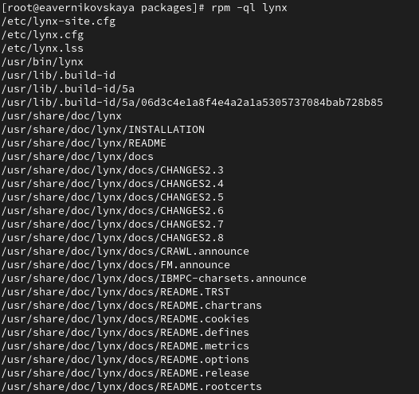

Список всех файлов в пакете (lynx)

## Использование rpm

Также выводим перечень файлов с документацией пакета, введя: *rpm -qd lynx* (рис. 31)

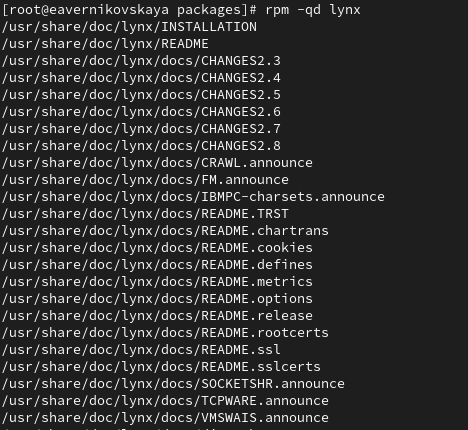

Перечень файлов с документацией пакета (lynx)

## Использование rpm

Смотрим файлы документации, применив команду *man lynx* (рис. 32)

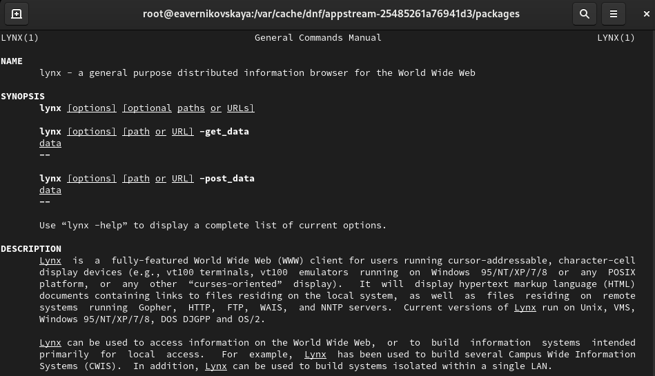

man lynx

## Использование rpm

Выодим на экран перечень и месторасположение конфигурационных файлов пакета: *rpm -qc lynx* (рис. 33)

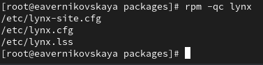

Конфигурационные файлы пакета (lynx)

## Использование rpm

Выводим на экран расположение и содержание скриптов, выполняемых при установке пакета: *rpm -q –scripts lynx*. Скриптов не было (рис. 34)

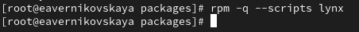

Скрипты (lynx)

## Использование rpm

В отдельном терминале под своей учётной записью запустите текстовый браузер lynx, чтобы проверить корректность установки пакета (рис. 35), (рис. 36)

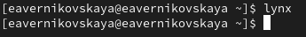

Команда для открытия lynx

## Использование rpm

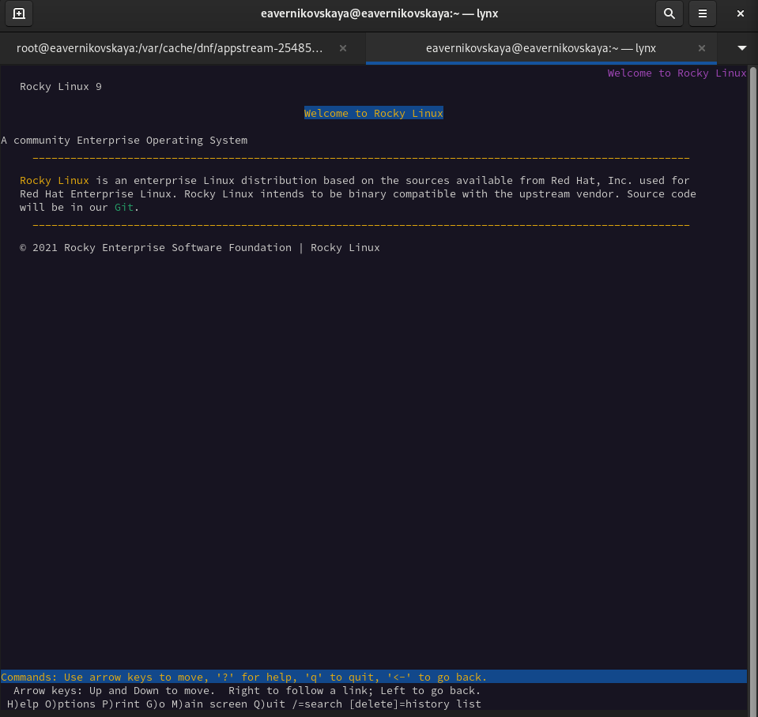

Браузер lynx

## Использование rpm

Возвращаемся в терминал с учётной записью root и удаляем пакет: *rpm -e lynx* (рис. 37)

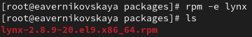

Удаление пакета lynx

## Использование rpm

Смотрим список пакетов dnsmasq: *dnf list dnsmasq*, а затем устанавливаем: *dnf install dnsmasq* (рис. 38), (рис. 39)

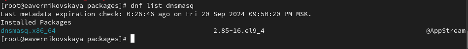

Список пакетов dnsmasq

## Использование rpm

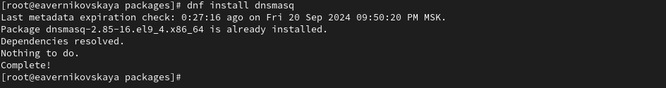

Установка dnsmasq

## Использование rpm

Далее проделываем те же действия, что и с lynx. Определяем расположение исполняемого файла (рис. 40)

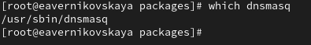

Расположение исполняемого файла (dnsmasq)

## Использование rpm

Определяем по имени файла, к какому пакету принадлежит dnsmasq (рис. 41)

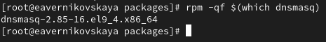

Пакет, к которому принадлежит dnsmasq

## Использование rpm

Получем дополнительную информацию о содержимом пакета (рис. 42)

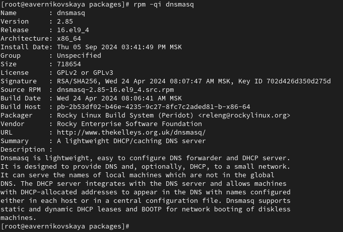

Информация о содержимом пакета (dnsmasq)

## Использование rpm

Получаем список всех файлов в пакете (рис. 43)

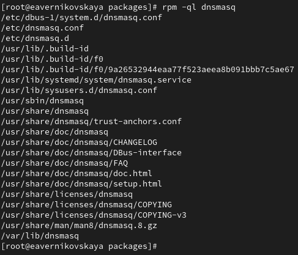

Список всех файлов в пакете (dnsmasq)

## Использование rpm

Также выводим перечень файлов с документацией пакета (рис. 44)

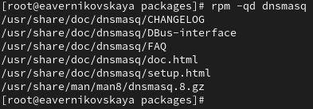

Перечень файлов с документацией пакета (dnsmasq)

## Использование rpm

Смотрим файлы документации, применив команду *man dnsmasq* (рис. 45)

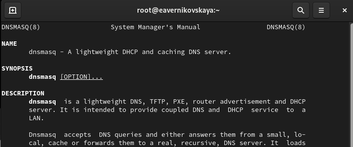

man dnsmasq

## Использование rpm

Выодим на экран перечень и месторасположение конфигурационных файлов пакета (рис. 46)

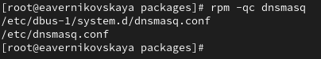

Конфигурационные файлы пакета (dnsmasq)

## Использование rpm

Выводим на экран расположение и содержание скриптов, выполняемых при установке пакета. На этот раз мы увидели скрипты, которые были выполнены при установке пакета. (рис. 47)

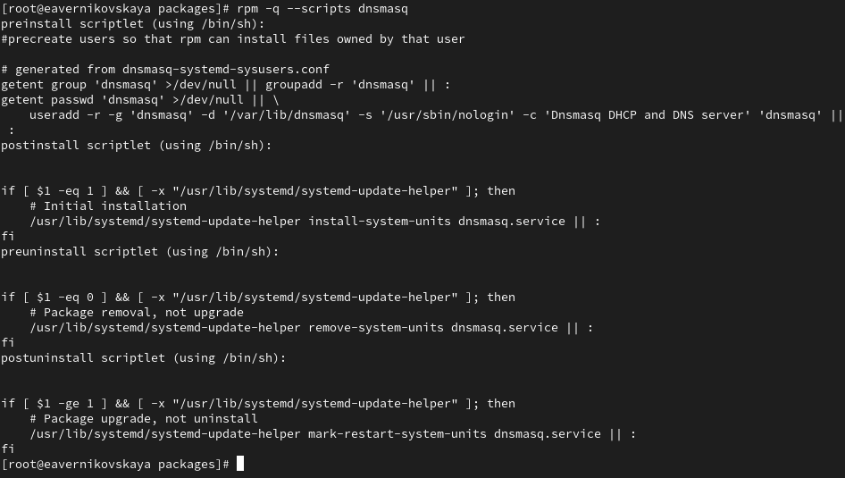

Скрипты (dnsmasq)

## Использование rpm

- Пре-установка (preinstall): Эти скрипты выполняются перед установкой пакета. Они могут использоваться для:
  - Подготовки системы к установке, например, создания каталогов или файлов конфигурации.
  - Проверки зависимостей или условий установки.
- Пост-установка (postinstall): Эти скрипты выполняются после завершения установки пакета. Они могут использоваться для:
  - Запуска сервиса, связанного с пакетом.
  - Обновления конфигурационных файлов.
  - Сообщения пользователю о завершении установки.

## Использование rpm

- Пре-удаление (preuninstall): Эти скрипты выполняются перед удалением пакета. Они могут использоваться для:
  - Остановки сервиса, связанного с пакетом.
  - Очистки временных файлов или каталогов.
- Пост-удаление (postuninstall): Эти скрипты выполняются после удаления пакета. Они могут использоваться для:
  - Удаления конфигурационных файлов или каталогов.
  - Удаления записей из системы.

## Использование rpm

Удаляем пакет (рис. 48)

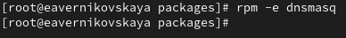

Удаление пакета dnsmasq

# Подведение итогов

## Выводы

В ходе выполнения лабораторной работы мы получили навыки работы с репозиториями и менеджерами пакетов.

## Список литературы

1. Лаборатораня работа №4 [Электронный ресурс] URL: https://esystem.rudn.ru/pluginfile.php/2400691/mod_resource/content/4/005-dnf.pdf